# 1000plus collateral flow & perfusion project

Ahmed Khalil

10 April, 2019

### Methods

**Reperfusion** is defined as the relative Tmax >6s change (% of baseline).  
Surrogates for good collateral flow in this study are:  
* Degree of reperfusion in non-recanalizers  
* The hypoperfusion intensity ration (HIR) at baseline (lower is better), defined according to:  
*Bang, O. Y. et al. (2008) âDeterminants of the distribution and severity of hypoperfusion in patients with ischemic stroke.â, Neurology*  
* The modified ASITN/SIR Collateral Flow Grading System (adapted for DSC-MRI, aka “Higashida score”), according to:  
*Campbell BC V, Christensen S, Tress BM, Churilov L, Desmond PM, Parsons MW, Alan Barber P, Levi CR, Bladin C, Donnan GA, Davis SM (2013) Failure of collateral blood flow is associated with infarct growth in ischemic stroke. J Cereb Blood Flow Metab* and dichotomized into good (3-4) and poor (0-2) according to: *Galinovic I, Kochova E, Khalil A, Villringer K, Piper SK, Fiebach JB (2018) The ratio between cerebral blood flow and Tmax predicts the quality of collaterals in acute ischemic stroke. PLoS One 13:e0190811*

The outcome measures in this study are:  
* Extent of reperfusion - relative Tmax >6s change (%)  
* Modified Rankin Scale at Day 90  
* Absolute infarct growth on DWI between days 1 and 2 (mL)  
* Absolute infarct growth between days 1 (DWI) and 5 (FLAIR) (mL)

All regression analyses are performed using a robust GLM (“High Breakdown And High Efficiency Robust Linear Regression”) using the R function “lmrob” from the “robustbase” package.  
Citation of package:  
*Martin Maechler, Peter Rousseeuw, Christophe Croux, Valentin Todorov, Andreas Ruckstuhl, Matias Salibian-Barrera, Tobias Verbeke, Manuel Koller, Eduardo L. T. Conceicao and Maria Anna di Palma (2018). robustbase: Basic Robust Statistics R package version 0.93-0. URL http://CRAN.R-project.org/package=robustbase*  
Citation of robust GLM:  
*Yohai, V. J. (1987). High breakdown-point and high efficiency robust estimates for regression. The Annals of Statistics, 642-656.*

**Power analysis:**

Sample size needed to detect a minimum effect size (R2/1-R2) of 0.1 at significance level of 0.05 and power of 0.8 with 8 predictors (including interactions) = 158. Performed with the R package “pwr”.  
Citation of package:  
*Stephane Champely (2018). pwr: Basic Functions for Power Analysis. R package version 1.2-2. https://CRAN.R-project.org/package=pwr*

### Descriptive statistics

```
## Factors are dropped from the summary
```

|  | N | Missing |  | Mean | SD |  | Min | Q1 | Median | Q3 | Max |
| --- | --- | --- | --- | --- | --- | --- | --- | --- | --- | --- | --- |
| ID | 186 | 0 |  | 156.76 | 96.20 |  | 2.00 | 71.00 | 154.50 | 242.00 | 323.00 |
| age | 186 | 0 |  | 71.72 | 13.23 |  | 23.00 | 66.00 | 74.00 | 82.00 | 93.00 |
| TSI | 186 | 0 |  | 6.97 | 6.81 |  | 0.00 | 1.50 | 3.55 | 12.10 | 24.00 |
| NIHSS_ad | 186 | 0 |  | 8.28 | 6.33 |  | 0.00 | 3.00 | 6.00 | 13.00 | 25.00 |
| NIHSS_dis | 185 | 1 |  | 4.39 | 5.66 |  | 0.00 | 0.00 | 2.00 | 6.00 | 29.00 |
| mRS_ad | 176 | 10 |  | 3.03 | 1.47 |  | 0.00 | 2.00 | 3.00 | 4.00 | 5.00 |
| mRS_dis | 173 | 13 |  | 2.19 | 1.64 |  | 0.00 | 1.00 | 2.00 | 4.00 | 6.00 |
| mRS_d90 | 149 | 37 |  | 2.30 | 1.92 |  | 0.00 | 1.00 | 2.00 | 4.00 | 6.00 |
| DWIvol_d1 | 186 | 0 |  | 15.26 | 27.48 |  | 0.00 | 0.99 | 5.40 | 18.55 | 231.36 |
| DWIvol_d2 | 186 | 0 |  | 31.18 | 49.31 |  | 0.00 | 3.07 | 12.39 | 39.64 | 324.01 |
| Tmax_vol_d1 | 186 | 0 |  | 45.47 | 49.77 |  | 0.00 | 11.00 | 26.60 | 67.00 | 258.63 |
| Tmax_vol_d2 | 186 | 0 |  | 26.83 | 85.47 |  | 0.00 | 1.00 | 7.00 | 27.50 | 1094.00 |
| DWIgrowth | 186 | 0 |  | 15.91 | 28.08 |  | -1.34 | 0.72 | 5.28 | 14.74 | 178.68 |
| rel_DWIgrowth | 186 | 0 |  | 357.66 | 1268.39 |  | -100.00 | 30.46 | 72.54 | 210.90 | 11561.11 |
| Tmax_change | 186 | 0 |  | -23.94 | 42.72 |  | -258.63 | -37.00 | -9.50 | -1.00 | 104.80 |
| relTmax_change | 186 | 0 |  | -29.35 | 143.98 |  | -100.00 | -95.56 | -57.30 | -7.69 | 1433.33 |
| mismatch_vol | 186 | 0 |  | 30.21 | 47.59 |  | -119.36 | 0.84 | 16.76 | 53.16 | 253.40 |
| infarct_growth_D5FLAIR | 141 | 45 |  | 26.87 | 43.08 |  | -3.68 | 1.97 | 8.50 | 29.69 | 222.72 |
| FLAIR_d5_vol | 141 | 45 |  | 41.57 | 57.20 |  | 0.01 | 5.90 | 18.50 | 55.50 | 300.40 |
| Tmax_D1_.2_volume | 186 | 0 |  | 83.28 | 60.82 |  | 1.05 | 33.30 | 72.75 | 120.61 | 317.11 |
| Tmax_D1_.4_volume | 186 | 0 |  | 64.04 | 57.58 |  | 0.14 | 19.03 | 46.88 | 93.02 | 317.11 |
| Tmax_D1_.8_volume | 186 | 0 |  | 27.50 | 34.79 |  | 0.00 | 2.82 | 12.70 | 38.68 | 172.25 |
| Tmax_D2_.2_volume | 186 | 0 |  | 48.02 | 53.07 |  | 0.00 | 8.02 | 30.91 | 62.36 | 281.54 |
| Tmax_D2_.4_volume | 186 | 0 |  | 32.84 | 44.49 |  | 0.00 | 2.41 | 16.44 | 40.61 | 226.83 |
| Tmax_D2_.8_volume | 186 | 0 |  | 11.60 | 21.45 |  | 0.00 | 0.08 | 1.62 | 14.76 | 130.90 |
| HIR1 | 186 | 0 |  | 0.27 | 0.24 |  | 0.00 | 0.07 | 0.23 | 0.42 | 1.00 |
| HIR2 | 178 | 8 |  | 0.18 | 0.24 |  | 0.00 | 0.01 | 0.07 | 0.29 | 1.00 |
| Tmax_D1_.6_volume | 186 | 0 |  | 45.47 | 49.77 |  | 0.00 | 11.00 | 26.60 | 67.00 | 258.63 |
| Tmax_D2_.6_volume | 186 | 0 |  | 26.83 | 85.47 |  | 0.00 | 1.00 | 7.00 | 27.50 | 1094.00 |
| Tmax_6_reperf_abs | 186 | 0 |  | 18.64 | 84.23 |  | -966.10 | 1.00 | 9.00 | 37.00 | 258.63 |
| Tmax_6_reperf_rel | 180 | 6 |  | 26.05 | 157.55 |  | -1433.33 | 11.09 | 66.18 | 96.09 | 100.00 |

```
##                     Level     N    %
## 1  higashida_D1         0     4  2.2
## 2                       1    31 16.7
## 3                       2    50 26.9
## 4                       3    49 26.3
## 5                       4    51 27.4
## 6                     NaN     0  0.0
## 7               <Missing>     1  0.5
## 8  higashida_D2         0     3  1.6
## 9                       1    22 11.8
## 10                      2    38 20.4
## 11                      3    39 21.0
## 12                      4    81 43.5
## 13                    NaN     0  0.0
## 14              <Missing>     3  1.6
## 15        Rekan      None    67 36.0
## 16                Partial    64 34.4
## 17                   Full    55 29.6
## 18  circulation  Anterior   142 76.3
## 19              Posterior    44 23.7
## 20          sex    Female    79 42.5
## 21                   Male   107 57.5
## 22       iv_tPR        No   106 57.0
## 23                    Yes    80 43.0
```

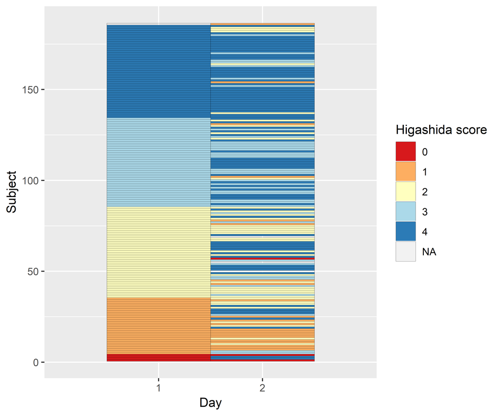

*Plot showing the change in Higashida scores over time for each patient.*

### Predictors of extent of reperfusion

|  | *Dependent variable:* |  |  |  |
| --- | --- | --- | --- | --- |
|  | Tmax_6_reperf_rel |  |  |  |
|  | (1) | (2) | (3) | (4) |
| NIHSS_ad | -0.605 (0.606) | -0.248 (0.563) | -0.225 (0.605) | 0.257 (0.536) |
|  | t = -0.998 | t = -0.440 | t = -0.372 | t = 0.479 |
|  | p = 0.320 | p = 0.661 | p = 0.711 | p = 0.633 |
| iv_tPRYes | 16.778** (7.372) | 6.089 (7.200) | 5.314 (7.271) | 5.530 (6.700) |
|  | t = 2.276 | t = 0.846 | t = 0.731 | t = 0.825 |
|  | p = 0.025 | p = 0.399 | p = 0.466 | p = 0.411 |
| RekanPartial |  | 26.774*** (7.780) | 22.873* (12.077) | 27.384*** (9.714) |
|  |  | t = 3.441 | t = 1.894 | t = 2.819 |
|  |  | p = 0.001 | p = 0.060 | p = 0.006 |
| RekanFull |  | 43.999*** (8.495) | 31.011** (13.239) | 33.681*** (10.641) |
|  |  | t = 5.179 | t = 2.342 | t = 3.165 |
|  |  | p = 0.00000 | p = 0.021 | p = 0.002 |
| HIR1 |  |  | -21.505 (25.723) |  |
|  |  |  | t = -0.836 |  |
|  |  |  | p = 0.405 |  |
| higashida_D1_binPoor |  |  |  | -24.774** (10.317) |
|  |  |  |  | t = -2.401 |
|  |  |  |  | p = 0.018 |
| circulationPosterior | -21.023** (8.773) | -15.293* (8.088) | -14.228* (8.132) | -11.229 (7.501) |
|  | t = -2.396 | t = -1.891 | t = -1.750 | t = -1.497 |
|  | p = 0.018 | p = 0.061 | p = 0.082 | p = 0.137 |
| RekanPartial:HIR1 |  |  | 14.252 (33.521) |  |
|  |  |  | t = 0.425 |  |
|  |  |  | p = 0.672 |  |
| RekanFull:HIR1 |  |  | 43.918 (36.192) |  |
|  |  |  | t = 1.213 |  |
|  |  |  | p = 0.227 |  |
| RekanPartial:higashida_D1_binPoor |  |  |  | -12.396 (14.319) |
|  |  |  |  | t = -0.866 |
|  |  |  |  | p = 0.388 |
| RekanFull:higashida_D1_binPoor |  |  |  | 21.163 (14.861) |
|  |  |  |  | t = 1.424 |
|  |  |  |  | p = 0.157 |
| Constant | 58.155*** (7.129) | 36.180*** (7.879) | 42.089*** (9.968) | 45.000*** (8.405) |
|  | t = 8.158 | t = 4.592 | t = 4.222 | t = 5.354 |
|  | p = 0.000 | p = 0.00001 | p = 0.00004 | p = 0.00000 |
| Observations | 180 | 180 | 180 | 180 |
| R<sup>2</sup> | 0.063 | 0.199 | 0.200 | 0.280 |
| Adjusted R<sup>2</sup> | 0.047 | 0.176 | 0.162 | 0.246 |
| Residual Std. Error | 46.630 (df = 176) | 42.332 (df = 174) | 42.418 (df = 171) | 39.082 (df = 171) |
| *Note:* | p<0.1; p<0.05; p<0.01 |  |  |  |

**1 vs 2**

| Statistic | N | Mean | St. Dev. | Min | Pctl(25) | Pctl(75) | Max |
| --- | --- | --- | --- | --- | --- | --- | --- |
| pseudoDf | 2 | 175.000 | 1.414 | 174 | 174.5 | 175.5 | 176 |
| Test.Stat | 1 | 27.943 |  | 27.943 | 27.943 | 27.943 | 27.943 |
| Df | 1 | 2.000 |  | 2.000 | 2.000 | 2.000 | 2.000 |
| Pr(> chisq) | 1 | 0.00000 |  | 0.00000 | 0.00000 | 0.00000 | 0.00000 |

**1 vs 3**

| Statistic | N | Mean | St. Dev. | Min | Pctl(25) | Pctl(75) | Max |
| --- | --- | --- | --- | --- | --- | --- | --- |
| pseudoDf | 2 | 173.500 | 3.536 | 171 | 172.2 | 174.8 | 176 |
| Test.Stat | 1 | 28.640 |  | 28.640 | 28.640 | 28.640 | 28.640 |
| Df | 1 | 5.000 |  | 5.000 | 5.000 | 5.000 | 5.000 |
| Pr(> chisq) | 1 | 0.00003 |  | 0.00003 | 0.00003 | 0.00003 | 0.00003 |

**1 vs 4**

| Statistic | N | Mean | St. Dev. | Min | Pctl(25) | Pctl(75) | Max |
| --- | --- | --- | --- | --- | --- | --- | --- |
| pseudoDf | 2 | 173.500 | 3.536 | 171 | 172.2 | 174.8 | 176 |
| Test.Stat | 1 | 50.570 |  | 50.570 | 50.570 | 50.570 | 50.570 |
| Df | 1 | 5.000 |  | 5.000 | 5.000 | 5.000 | 5.000 |
| Pr(> chisq) | 1 | 0.000 |  | 0.000 | 0.000 | 0.000 | 0.000 |

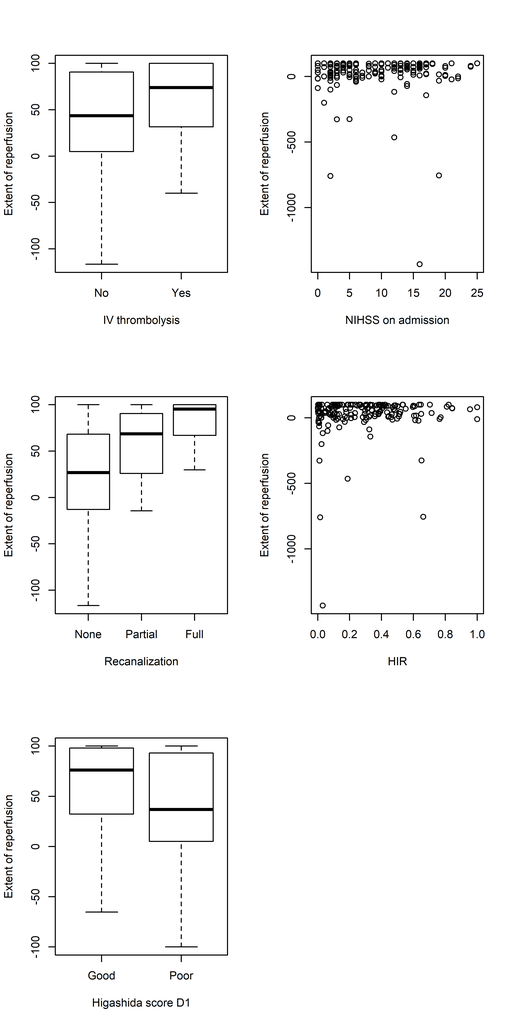

#### Predictors of extent of reperfusion in non-recanalizers

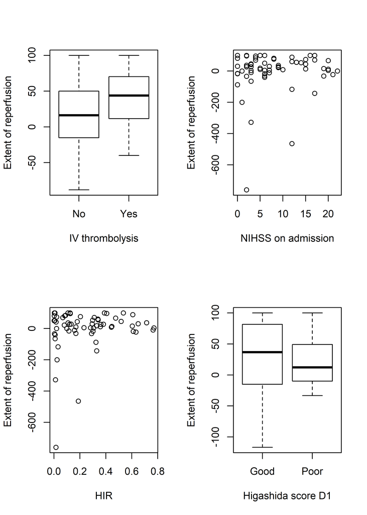

|  | *Dependent variable:* |  |  |
| --- | --- | --- | --- |
|  | Tmax_6_reperf_rel |  |  |
|  | (1) | (2) | (3) |
| NIHSS_ad | -2.001* (1.178) | -2.019 (1.262) | -1.625 (1.236) |
|  | t = -1.698 | t = -1.600 | t = -1.315 |
|  | p = 0.095 | p = 0.115 | p = 0.194 |
| iv_tPRYes | 23.317 (15.320) | 23.262 (15.535) | 22.977 (15.224) |
|  | t = 1.522 | t = 1.497 | t = 1.509 |
|  | p = 0.134 | p = 0.140 | p = 0.137 |
| HIR1 |  | 0.791 (32.130) |  |
|  |  | t = 0.025 |  |
|  |  | p = 0.981 |  |
| higashida_D1_binPoor |  |  | -12.381 (13.811) |
|  |  |  | t = -0.896 |
|  |  |  | p = 0.374 |
| circulationPosterior | -50.305*** (15.323) | -50.572*** (15.517) | -46.684*** (15.405) |
|  | t = -3.283 | t = -3.259 | t = -3.030 |
|  | p = 0.002 | p = 0.002 | p = 0.004 |
| Constant | 52.959*** (13.468) | 52.938*** (14.532) | 55.409*** (13.696) |
|  | t = 3.932 | t = 3.643 | t = 4.046 |
|  | p = 0.0003 | p = 0.001 | p = 0.0002 |
| Observations | 64 | 64 | 64 |
| R<sup>2</sup> | 0.178 | 0.179 | 0.182 |
| Adjusted R<sup>2</sup> | 0.137 | 0.123 | 0.127 |
| Residual Std. Error | 51.115 (df = 60) | 51.770 (df = 59) | 50.769 (df = 59) |
| *Note:* | p<0.1; p<0.05; p<0.01 |  |  |

**1 vs 2**

| Statistic | N | Mean | St. Dev. | Min | Pctl(25) | Pctl(75) | Max |
| --- | --- | --- | --- | --- | --- | --- | --- |
| pseudoDf | 2 | 59.500 | 0.707 | 59 | 59.2 | 59.8 | 60 |
| Test.Stat | 1 | 0.001 |  | 0.001 | 0.001 | 0.001 | 0.001 |
| Df | 1 | 1.000 |  | 1.000 | 1.000 | 1.000 | 1.000 |
| Pr(> chisq) | 1 | 0.980 |  | 0.980 | 0.980 | 0.980 | 0.980 |

**1 vs 3**

| Statistic | N | Mean | St. Dev. | Min | Pctl(25) | Pctl(75) | Max |
| --- | --- | --- | --- | --- | --- | --- | --- |
| pseudoDf | 2 | 59.500 | 0.707 | 59 | 59.2 | 59.8 | 60 |
| Test.Stat | 1 | 0.804 |  | 0.804 | 0.804 | 0.804 | 0.804 |
| Df | 1 | 1.000 |  | 1.000 | 1.000 | 1.000 | 1.000 |
| Pr(> chisq) | 1 | 0.370 |  | 0.370 | 0.370 | 0.370 | 0.370 |

#### Predictors of extent of reperfusion in partial recanalizers

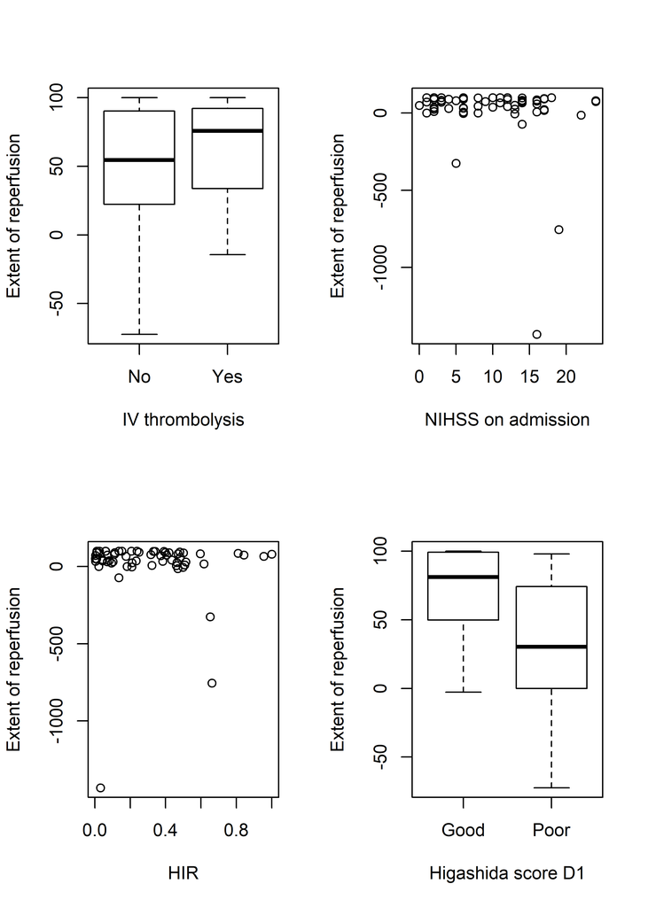

|  | *Dependent variable:* |  |  |
| --- | --- | --- | --- |
|  | Tmax_6_reperf_rel |  |  |
|  | (1) | (2) | (3) |
| NIHSS_ad | -0.094 (0.842) | 0.065 (0.915) | 0.648 (0.769) |
|  | t = -0.112 | t = 0.071 | t = 0.842 |
|  | p = 0.912 | p = 0.944 | p = 0.404 |
| iv_tPRYes | 8.787 (10.907) | 9.386 (10.981) | 5.977 (9.634) |
|  | t = 0.806 | t = 0.855 | t = 0.620 |
|  | p = 0.424 | p = 0.397 | p = 0.538 |
| HIR1 |  | -10.365 (23.359) |  |
|  |  | t = -0.444 |  |
|  |  | p = 0.659 |  |
| higashida_D1_binPoor |  |  | -38.124*** (9.468) |
|  |  |  | t = -4.027 |
|  |  |  | p = 0.0002 |
| circulationPosterior | -6.031 (12.875) | -6.912 (13.138) | -6.199 (11.212) |
|  | t = -0.468 | t = -0.526 | t = -0.553 |
|  | p = 0.642 | p = 0.601 | p = 0.583 |
| Constant | 59.245*** (9.702) | 60.698*** (10.339) | 68.511*** (8.789) |
|  | t = 6.106 | t = 5.871 | t = 7.795 |
|  | p = 0.00000 | p = 0.00000 | p = 0.000 |
| Observations | 62 | 62 | 62 |
| R<sup>2</sup> | 0.016 | 0.020 | 0.245 |
| Adjusted R<sup>2</sup> | -0.035 | -0.049 | 0.192 |
| Residual Std. Error | 39.286 (df = 58) | 39.620 (df = 57) | 34.256 (df = 57) |
| *Note:* | p<0.1; p<0.05; p<0.01 |  |  |

**1 vs 2**

| Statistic | N | Mean | St. Dev. | Min | Pctl(25) | Pctl(75) | Max |
| --- | --- | --- | --- | --- | --- | --- | --- |
| pseudoDf | 2 | 57.500 | 0.707 | 57 | 57.2 | 57.8 | 58 |
| Test.Stat | 1 | 0.197 |  | 0.197 | 0.197 | 0.197 | 0.197 |
| Df | 1 | 1.000 |  | 1.000 | 1.000 | 1.000 | 1.000 |
| Pr(> chisq) | 1 | 0.657 |  | 0.657 | 0.657 | 0.657 | 0.657 |

**1 vs 3**

| Statistic | N | Mean | St. Dev. | Min | Pctl(25) | Pctl(75) | Max |
| --- | --- | --- | --- | --- | --- | --- | --- |
| pseudoDf | 2 | 57.500 | 0.707 | 57 | 57.2 | 57.8 | 58 |
| Test.Stat | 1 | 16.215 |  | 16.215 | 16.215 | 16.215 | 16.215 |
| Df | 1 | 1.000 |  | 1.000 | 1.000 | 1.000 | 1.000 |
| Pr(> chisq) | 1 | 0.0001 |  | 0.0001 | 0.0001 | 0.0001 | 0.0001 |

#### Predictors of extent of reperfusion in full recanalizers

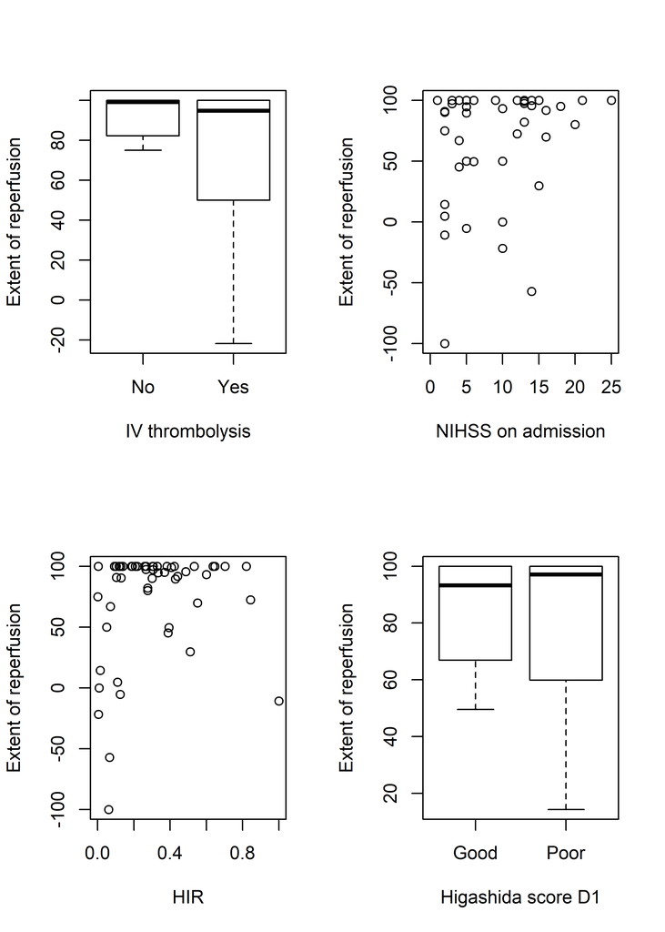

|  | *Dependent variable:* |  |  |
| --- | --- | --- | --- |
|  | Tmax_6_reperf_rel |  |  |
|  | (1) | (2) | (3) |
| NIHSS_ad | -0.182 (0.255) | -0.159 (0.881) | -0.205 (0.282) |
|  | t = -0.715 | t = -0.180 | t = -0.727 |
|  | p = 0.478 | p = 0.858 | p = 0.471 |
| iv_tPRYes | -0.637 (3.239) | -11.940 (9.757) | -1.634 (3.581) |
|  | t = -0.197 | t = -1.224 | t = -0.456 |
|  | p = 0.845 | p = 0.227 | p = 0.651 |
| HIR1 |  | 48.328** (23.286) |  |
|  |  | t = 2.075 |  |
|  |  | p = 0.044 |  |
| higashida_D1_binPoor |  |  | 3.469 (3.425) |
|  |  |  | t = 1.013 |
|  |  |  | p = 0.317 |
| circulationPosterior | -2.354 (3.978) | 9.712 (12.154) | -1.184 (4.438) |
|  | t = -0.592 | t = 0.799 | t = -0.267 |
|  | p = 0.557 | p = 0.429 | p = 0.791 |
| Constant | 97.038*** (3.269) | 75.251*** (10.074) | 95.283*** (3.712) |
|  | t = 29.688 | t = 7.470 | t = 25.670 |
|  | p = 0.000 | p = 0.000 | p = 0.000 |
| Observations | 54 | 54 | 54 |
| R<sup>2</sup> | 0.014 | 0.099 | 0.028 |
| Adjusted R<sup>2</sup> | -0.045 | 0.025 | -0.051 |
| Residual Std. Error | 10.580 (df = 50) | 32.879 (df = 49) | 11.764 (df = 49) |
| *Note:* | p<0.1; p<0.05; p<0.01 |  |  |

**1 vs 2**

| Statistic | N | Mean | St. Dev. | Min | Pctl(25) | Pctl(75) | Max |
| --- | --- | --- | --- | --- | --- | --- | --- |
| pseudoDf | 2 | 49.500 | 0.707 | 49 | 49.2 | 49.8 | 50 |
| Test.Stat | 1 | 4.307 |  | 4.307 | 4.307 | 4.307 | 4.307 |
| Df | 1 | 1.000 |  | 1.000 | 1.000 | 1.000 | 1.000 |
| Pr(> chisq) | 1 | 0.038 |  | 0.038 | 0.038 | 0.038 | 0.038 |

**1 vs 3**

| Statistic | N | Mean | St. Dev. | Min | Pctl(25) | Pctl(75) | Max |
| --- | --- | --- | --- | --- | --- | --- | --- |
| pseudoDf | 2 | 49.500 | 0.707 | 49 | 49.2 | 49.8 | 50 |
| Test.Stat | 1 | 1.026 |  | 1.026 | 1.026 | 1.026 | 1.026 |
| Df | 1 | 1.000 |  | 1.000 | 1.000 | 1.000 | 1.000 |
| Pr(> chisq) | 1 | 0.311 |  | 0.311 | 0.311 | 0.311 | 0.311 |

### Predictors of clinical outcome

|  | *Dependent variable:* |  |  |  |  |  |
| --- | --- | --- | --- | --- | --- | --- |
|  | mRS_d90 |  |  |  |  |  |
|  | (1) | (2) | (3) | (4) | (5) | (6) |
| HIR1 | 2.145*** (0.727) | 0.765 (0.648) |  |  |  |  |
|  | t = 2.952 | t = 1.180 |  |  |  |  |
|  | p = 0.004 | p = 0.241 |  |  |  |  |
| NIHSS_ad |  | 0.162*** (0.026) |  | 0.165*** (0.026) |  | 0.171*** (0.025) |
|  |  | t = 6.211 |  | t = 6.335 |  | t = 6.753 |
|  |  | p = 0.000 |  | p = 0.000 |  | p = 0.000 |
| iv_tPRYes |  | -0.579* (0.304) |  | -0.589* (0.304) |  | -0.565* (0.314) |
|  |  | t = -1.901 |  | t = -1.936 |  | t = -1.798 |
|  |  | p = 0.060 |  | p = 0.055 |  | p = 0.075 |
| RekanPartial |  | -1.060*** (0.345) |  | -1.023*** (0.346) | -0.315 (0.558) | -0.923* (0.480) |
|  |  | t = -3.072 |  | t = -2.953 | t = -0.565 | t = -1.921 |
|  |  | p = 0.003 |  | p = 0.004 | p = 0.574 | p = 0.057 |
| RekanFull |  | -1.416*** (0.372) |  | -1.387*** (0.371) | -1.909*** (0.612) | -1.299** (0.550) |
|  |  | t = -3.811 |  | t = -3.740 | t = -3.119 | t = -2.364 |
|  |  | p = 0.0003 |  | p = 0.0003 | p = 0.003 | p = 0.020 |
| Tmax_6_reperf_rel |  | -0.001 (0.001) |  | -0.001 (0.001) | 0.0002 (0.002) | -0.0004 (0.002) |
|  |  | t = -0.567 |  | t = -0.397 | t = 0.135 | t = -0.278 |
|  |  | p = 0.572 |  | p = 0.693 | p = 0.893 | p = 0.782 |
| higashida_D1_binPoor |  |  | 1.039*** (0.330) | 0.256 (0.293) |  |  |
|  |  |  | t = 3.151 | t = 0.875 |  |  |
|  |  |  | p = 0.002 | p = 0.384 |  |  |
| circulationPosterior | 0.177 (0.368) | 0.385 (0.316) | 0.134 (0.364) | 0.396 (0.315) | -0.190 (0.363) | 0.383 (0.319) |
|  | t = 0.480 | t = 1.219 | t = 0.368 | t = 1.257 | t = -0.523 | t = 1.200 |
|  | p = 0.633 | p = 0.226 | p = 0.714 | p = 0.211 | p = 0.603 | p = 0.233 |
| RekanPartial:Tmax_6_reperf_rel |  |  |  |  | -0.009 (0.007) | -0.003 (0.006) |
|  |  |  |  |  | t = -1.229 | t = -0.418 |
|  |  |  |  |  | p = 0.222 | p = 0.677 |
| RekanFull:Tmax_6_reperf_rel |  |  |  |  | 0.002 (0.007) | -0.002 (0.006) |
|  |  |  |  |  | t = 0.289 | t = -0.312 |
|  |  |  |  |  | p = 0.774 | p = 0.756 |
| Constant | 1.639*** (0.275) | 1.782*** (0.333) | 1.760*** (0.241) | 1.821*** (0.329) | 3.164*** (0.302) | 1.902*** (0.322) |
|  | t = 5.958 | t = 5.359 | t = 7.307 | t = 5.543 | t = 10.492 | t = 5.901 |
|  | p = 0.00000 | p = 0.00000 | p = 0.000 | p = 0.00000 | p = 0.000 | p = 0.00000 |
| Observations | 149 | 144 | 149 | 144 | 144 | 144 |
| R<sup>2</sup> | 0.059 | 0.368 | 0.066 | 0.364 | 0.138 | 0.362 |
| Adjusted R<sup>2</sup> | 0.046 | 0.336 | 0.054 | 0.331 | 0.100 | 0.324 |
| Residual Std. Error | 1.964 (df = 146) | 1.588 (df = 136) | 1.952 (df = 146) | 1.592 (df = 136) | 1.874 (df = 137) | 1.600 (df = 135) |
| *Note:* | p<0.1; p<0.05; p<0.01 |  |  |  |  |  |

**1 vs 2**

| Statistic | N | Mean | St. Dev. | Min | Pctl(25) | Pctl(75) | Max |
| --- | --- | --- | --- | --- | --- | --- | --- |
| pseudoDf | 2 | 138.500 | 3.536 | 136 | 137.2 | 139.8 | 141 |
| Test.Stat | 1 | 66.593 |  | 66.593 | 66.593 | 66.593 | 66.593 |
| Df | 1 | 5.000 |  | 5.000 | 5.000 | 5.000 | 5.000 |
| Pr(> chisq) | 1 | 0.000 |  | 0.000 | 0.000 | 0.000 | 0.000 |

**1 vs 3**

| Statistic | N | Mean | St. Dev. | Min | Pctl(25) | Pctl(75) | Max |
| --- | --- | --- | --- | --- | --- | --- | --- |
| pseudoDf | 2 | 138.500 | 3.536 | 136 | 137.2 | 139.8 | 141 |
| Test.Stat | 1 | 64.177 |  | 64.177 | 64.177 | 64.177 | 64.177 |
| Df | 1 | 5.000 |  | 5.000 | 5.000 | 5.000 | 5.000 |
| Pr(> chisq) | 1 | 0.000 |  | 0.000 | 0.000 | 0.000 | 0.000 |

**1 vs 4**

| Statistic | N | Mean | St. Dev. | Min | Pctl(25) | Pctl(75) | Max |
| --- | --- | --- | --- | --- | --- | --- | --- |
| pseudoDf | 2 | 136.000 | 1.414 | 135 | 135.5 | 136.5 | 137 |
| Test.Stat | 1 | 46.109 |  | 46.109 | 46.109 | 46.109 | 46.109 |
| Df | 1 | 2.000 |  | 2.000 | 2.000 | 2.000 | 2.000 |
| Pr(> chisq) | 1 | 0.000 |  | 0.000 | 0.000 | 0.000 | 0.000 |

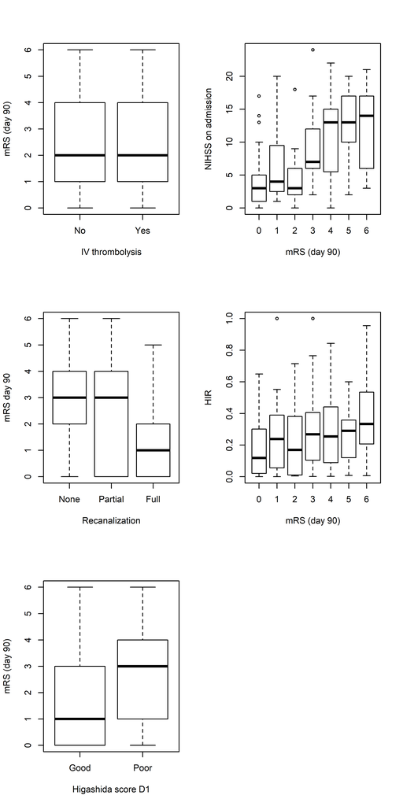

### Predictors of absolute infarct growth (D1 - D2)

|  | *Dependent variable:* |  |  |  |  |  |
| --- | --- | --- | --- | --- | --- | --- |
|  | DWIgrowth |  |  |  |  |  |
|  | (1) | (2) | (3) | (4) | (5) | (6) |
| HIR1 | 13.157*** (2.364) | 12.882*** (3.200) |  |  |  |  |
|  | t = 5.566 | t = 4.026 |  |  |  |  |
|  | p = 0.00000 | p = 0.0001 |  |  |  |  |
| NIHSS_ad |  | 0.541*** (0.127) |  | 0.495*** (0.114) |  | 0.615*** (0.120) |
|  |  | t = 4.243 |  | t = 4.329 |  | t = 5.132 |
|  |  | p = 0.00004 |  | p = 0.00003 |  | p = 0.00000 |
| iv_tPRYes |  | 0.172 (1.510) |  | -0.245 (1.374) |  | 0.630 (1.469) |
|  |  | t = 0.114 |  | t = -0.178 |  | t = 0.429 |
|  |  | p = 0.910 |  | p = 0.859 |  | p = 0.669 |
| Tmax_6_reperf_rel |  | -0.025*** (0.005) |  | -0.008 (0.006) | 0.003 (0.008) | -0.002 (0.008) |
|  |  | t = -5.480 |  | t = -1.287 | t = 0.352 | t = -0.245 |
|  |  | p = 0.00000 |  | p = 0.200 | p = 0.726 | p = 0.807 |
| RekanPartial |  | 0.401 (1.675) |  | 0.576 (1.546) | 2.073 (1.482) | 1.228 (1.628) |
|  |  | t = 0.239 |  | t = 0.373 | t = 1.398 | t = 0.755 |
|  |  | p = 0.812 |  | p = 0.710 | p = 0.164 | p = 0.452 |
| RekanFull |  | 0.002 (1.799) |  | -0.159 (1.653) | 1.086 (2.185) | 0.114 (2.497) |
|  |  | t = 0.001 |  | t = -0.096 | t = 0.497 | t = 0.046 |
|  |  | p = 1.000 |  | p = 0.924 | p = 0.620 | p = 0.964 |
| higashida_D1_binPoor |  |  | 5.223*** (0.978) | 5.171*** (1.278) |  |  |
|  |  |  | t = 5.340 | t = 4.047 |  |  |
|  |  |  | p = 0.00000 | p = 0.0001 |  |  |
| circulationPosterior | 0.169 (1.178) | 1.536 (1.607) | -0.055 (1.094) | 1.566 (1.445) | -0.451 (1.384) | 1.400 (1.558) |
|  | t = 0.143 | t = 0.956 | t = -0.051 | t = 1.083 | t = -0.326 | t = 0.898 |
|  | p = 0.887 | p = 0.341 | p = 0.960 | p = 0.281 | p = 0.745 | p = 0.371 |
| RekanPartial:Tmax_6_reperf_rel |  |  |  |  | -0.033*** (0.009) | -0.025** (0.010) |
|  |  |  |  |  | t = -3.691 | t = -2.554 |
|  |  |  |  |  | p = 0.0003 | p = 0.012 |
| RekanFull:Tmax_6_reperf_rel |  |  |  |  | -0.012 (0.024) | -0.012 (0.026) |
|  |  |  |  |  | t = -0.509 | t = -0.478 |
|  |  |  |  |  | p = 0.612 | p = 0.634 |
| Constant | 2.526*** (0.840) | 0.392 (1.656) | 3.381*** (0.682) | 0.742 (1.471) | 5.990*** (1.158) | 2.041 (1.537) |
|  | t = 3.006 | t = 0.236 | t = 4.957 | t = 0.505 | t = 5.173 | t = 1.328 |
|  | p = 0.004 | p = 0.814 | p = 0.00001 | p = 0.615 | p = 0.00000 | p = 0.186 |
| Observations | 186 | 180 | 186 | 180 | 180 | 180 |
| R<sup>2</sup> | 0.135 | 0.317 | 0.128 | 0.213 | 0.176 | 0.258 |
| Adjusted R<sup>2</sup> | 0.126 | 0.290 | 0.118 | 0.180 | 0.147 | 0.223 |
| Residual Std. Error | 7.129 (df = 183) | 8.410 (df = 172) | 6.654 (df = 183) | 7.904 (df = 172) | 8.456 (df = 173) | 8.693 (df = 171) |
| *Note:* | p<0.1; p<0.05; p<0.01 |  |  |  |  |  |

**1 vs 2**

| Statistic | N | Mean | St. Dev. | Min | Pctl(25) | Pctl(75) | Max |
| --- | --- | --- | --- | --- | --- | --- | --- |
| pseudoDf | 2 | 174.500 | 3.536 | 172 | 173.2 | 175.8 | 177 |
| Test.Stat | 1 | 55.308 |  | 55.308 | 55.308 | 55.308 | 55.308 |
| Df | 1 | 5.000 |  | 5.000 | 5.000 | 5.000 | 5.000 |
| Pr(> chisq) | 1 | 0.000 |  | 0.000 | 0.000 | 0.000 | 0.000 |

**1 vs 3**

| Statistic | N | Mean | St. Dev. | Min | Pctl(25) | Pctl(75) | Max |
| --- | --- | --- | --- | --- | --- | --- | --- |
| pseudoDf | 2 | 174.500 | 3.536 | 172 | 173.2 | 175.8 | 177 |
| Test.Stat | 1 | 21.263 |  | 21.263 | 21.263 | 21.263 | 21.263 |
| Df | 1 | 5.000 |  | 5.000 | 5.000 | 5.000 | 5.000 |
| Pr(> chisq) | 1 | 0.001 |  | 0.001 | 0.001 | 0.001 | 0.001 |

**1 vs 4**

| Statistic | N | Mean | St. Dev. | Min | Pctl(25) | Pctl(75) | Max |
| --- | --- | --- | --- | --- | --- | --- | --- |
| pseudoDf | 2 | 172.000 | 1.414 | 171 | 171.5 | 172.5 | 173 |
| Test.Stat | 1 | 29.497 |  | 29.497 | 29.497 | 29.497 | 29.497 |
| Df | 1 | 2.000 |  | 2.000 | 2.000 | 2.000 | 2.000 |
| Pr(> chisq) | 1 | 0.00000 |  | 0.00000 | 0.00000 | 0.00000 | 0.00000 |

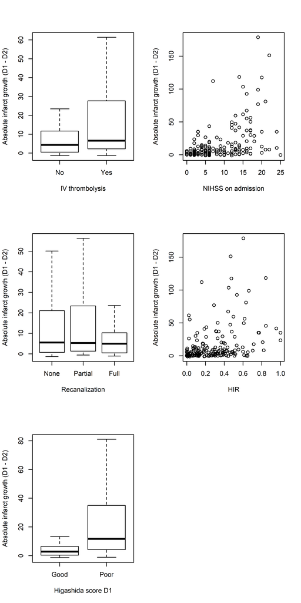

### Predictors of absolute infarct growth (D1 - D5)

|  | *Dependent variable:* |  |  |  |  |  |
| --- | --- | --- | --- | --- | --- | --- |
|  | infarct_growth_D5FLAIR |  |  |  |  |  |
|  | (1) | (2) | (3) | (4) | (5) | (6) |
| HIR1 | 23.701*** (5.822) | 17.300*** (6.280) |  |  |  |  |
|  | t = 4.071 | t = 2.755 |  |  |  |  |
|  | p = 0.0001 | p = 0.007 |  |  |  |  |
| NIHSS_ad |  | 1.184*** (0.265) |  | 1.129*** (0.247) |  | 1.536*** (0.271) |
|  |  | t = 4.463 |  | t = 4.571 |  | t = 5.671 |
|  |  | p = 0.00002 |  | p = 0.00002 |  | p = 0.00000 |
| iv_tPRYes |  | -0.102 (2.876) |  | 0.015 (2.727) |  | 0.652 (3.062) |
|  |  | t = -0.036 |  | t = 0.005 |  | t = 0.213 |
|  |  | p = 0.972 |  | p = 0.996 |  | p = 0.832 |
| RekanPartial |  | -0.010 (3.256) |  | 1.538 (3.102) | 10.059*** (3.475) | 6.325* (3.411) |
|  |  | t = -0.003 |  | t = 0.496 | t = 2.894 | t = 1.854 |
|  |  | p = 0.998 |  | p = 0.621 | p = 0.005 | p = 0.067 |
| RekanFull |  | -2.160 (3.491) |  | -2.402 (3.313) | -1.055 (5.183) | -2.898 (5.167) |
|  |  | t = -0.619 |  | t = -0.725 | t = -0.203 | t = -0.561 |
|  |  | p = 0.538 |  | p = 0.470 | p = 0.840 | p = 0.576 |
| Tmax_6_reperf_rel |  | -0.002 (0.013) |  | 0.005 (0.012) | 0.014 (0.017) | 0.004 (0.016) |
|  |  | t = -0.148 |  | t = 0.368 | t = 0.859 | t = 0.271 |
|  |  | p = 0.883 |  | p = 0.714 | p = 0.393 | p = 0.787 |
| higashida_D1_binPoor |  |  | 10.572*** (2.429) | 9.375*** (2.504) |  |  |
|  |  |  | t = 4.352 | t = 3.744 |  |  |
|  |  |  | p = 0.00003 | p = 0.0003 |  |  |
| circulationPosterior | -1.105 (2.822) | 1.381 (2.970) | -1.399 (2.668) | 0.782 (2.809) | -2.640 (3.236) | 1.360 (3.210) |
|  | t = -0.392 | t = 0.465 | t = -0.524 | t = 0.279 | t = -0.816 | t = 0.424 |
|  | p = 0.696 | p = 0.643 | p = 0.601 | p = 0.782 | p = 0.417 | p = 0.673 |
| RekanPartial:Tmax_6_reperf_rel |  |  |  |  | -0.117*** (0.019) | -0.099*** (0.019) |
|  |  |  |  |  | t = -6.084 | t = -5.302 |
|  |  |  |  |  | p = 0.000 | p = 0.00000 |
| RekanFull:Tmax_6_reperf_rel |  |  |  |  | -0.017 (0.055) | 0.002 (0.053) |
|  |  |  |  |  | t = -0.309 | t = 0.043 |
|  |  |  |  |  | p = 0.758 | p = 0.966 |
| Constant | 6.649*** (2.082) | 0.998 (3.141) | 7.762*** (1.723) | 0.939 (2.947) | 12.834*** (2.733) | 2.635 (3.235) |
|  | t = 3.193 | t = 0.318 | t = 4.504 | t = 0.319 | t = 4.697 | t = 0.814 |
|  | p = 0.002 | p = 0.752 | p = 0.00002 | p = 0.751 | p = 0.00001 | p = 0.417 |
| Observations | 141 | 138 | 141 | 138 | 138 | 138 |
| R<sup>2</sup> | 0.115 | 0.251 | 0.129 | 0.281 | 0.490 | 0.579 |
| Adjusted R<sup>2</sup> | 0.102 | 0.211 | 0.116 | 0.242 | 0.466 | 0.552 |
| Residual Std. Error | 14.323 (df = 138) | 14.799 (df = 130) | 13.614 (df = 138) | 14.060 (df = 130) | 16.765 (df = 131) | 16.086 (df = 129) |
| *Note:* | p<0.1; p<0.05; p<0.01 |  |  |  |  |  |

**1 vs 2**

| Statistic | N | Mean | St. Dev. | Min | Pctl(25) | Pctl(75) | Max |
| --- | --- | --- | --- | --- | --- | --- | --- |
| pseudoDf | 2 | 132.500 | 3.536 | 130 | 131.2 | 133.8 | 135 |
| Test.Stat | 1 | 23.149 |  | 23.149 | 23.149 | 23.149 | 23.149 |
| Df | 1 | 5.000 |  | 5.000 | 5.000 | 5.000 | 5.000 |
| Pr(> chisq) | 1 | 0.0003 |  | 0.0003 | 0.0003 | 0.0003 | 0.0003 |

**1 vs 3**

| Statistic | N | Mean | St. Dev. | Min | Pctl(25) | Pctl(75) | Max |
| --- | --- | --- | --- | --- | --- | --- | --- |
| pseudoDf | 2 | 132.500 | 3.536 | 130 | 131.2 | 133.8 | 135 |
| Test.Stat | 1 | 28.089 |  | 28.089 | 28.089 | 28.089 | 28.089 |
| Df | 1 | 5.000 |  | 5.000 | 5.000 | 5.000 | 5.000 |
| Pr(> chisq) | 1 | 0.00003 |  | 0.00003 | 0.00003 | 0.00003 | 0.00003 |

**1 vs 4**

| Statistic | N | Mean | St. Dev. | Min | Pctl(25) | Pctl(75) | Max |
| --- | --- | --- | --- | --- | --- | --- | --- |
| pseudoDf | 2 | 130.000 | 1.414 | 129 | 129.5 | 130.5 | 131 |
| Test.Stat | 1 | 35.581 |  | 35.581 | 35.581 | 35.581 | 35.581 |
| Df | 1 | 2.000 |  | 2.000 | 2.000 | 2.000 | 2.000 |
| Pr(> chisq) | 1 | 0.00000 |  | 0.00000 | 0.00000 | 0.00000 | 0.00000 |

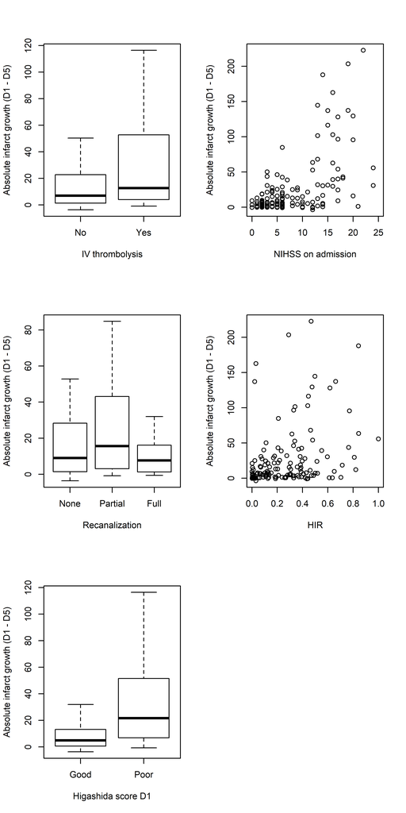

### Predictors of collateral flow defined by Higashida score

|  | *Dependent variable:* |
| --- | --- |
|  | higashida_D1_bin |
| NIHSS_ad | 0.038 (0.035) |
|  | t = 1.093 |
|  | p = 0.275 |
| age | 0.003 (0.016) |
|  | t = 0.204 |
|  | p = 0.839 |
| sexMale | 0.754* (0.407) |
|  | t = 1.852 |
|  | p = 0.065 |
| TSI | -0.022 (0.028) |
|  | t = -0.793 |
|  | p = 0.428 |
| DWIvol_d1 | 0.081*** (0.020) |
|  | t = 3.974 |
|  | p = 0.0001 |
| circulationPosterior | -0.018 (0.432) |
|  | t = -0.042 |
|  | p = 0.967 |
| Constant | -1.855 (1.242) |
|  | t = -1.494 |
|  | p = 0.136 |
| Observations | 186 |
| *Note:* | p<0.1; p<0.05; p<0.01 |

### Predictors of collateral flow defined by HIR

|  | *Dependent variable:* |
| --- | --- |
|  | HIR1 |
| NIHSS_ad | 0.038 (0.030) |
|  | t = 1.256 |
|  | p = 0.210 |
| age | 0.012 (0.014) |
|  | t = 0.820 |
|  | p = 0.412 |
| sexMale | 0.104 (0.373) |
|  | t = 0.278 |
|  | p = 0.781 |
| TSI | -0.015 (0.027) |
|  | t = -0.560 |
|  | p = 0.576 |
| DWIvol_d1 | 0.008 (0.006) |
|  | t = 1.166 |
|  | p = 0.244 |
| circulationPosterior | -0.143 (0.429) |
|  | t = -0.334 |
|  | p = 0.739 |
| Constant | -2.071* (1.149) |
|  | t = -1.803 |
|  | p = 0.072 |
| Observations | 186 |
| *Note:* | p<0.1; p<0.05; p<0.01 |